# DARL Project Status Notebook

MORTALITYMINDER

Jocelyn McConnon

9 October 2020

## Weekly Work Summary

- RCS ID: mcconj2
- Project Name: MORTALITYMINDER
- Summary of work since last week
  - drafted third use case on national trends in determinants
  - determined I would not analyze Rensselaer county, NY
  - determined I would analyze Sierra county, NM
  - added New Mexico as a state for analysis
  - performed analysis on Sierra county
  - performed analysis on New Mexico
  - met with Sky and discussed our case studies
  - created a shared Google doc to colaborate in
  - looked at MortalityMinder Overview slides
  - looked at Bennett’s PIE talk on MortalityMinder
  - made a Google slides to begin presentation slides
  - began use case presentation slides
- List of presentations, papers, or other output
  - https://docs.google.com/document/d/15YSeTAvyaxTF1yh7QI6EjTNqYnHySU4qbgK42rD5mVc/edit?usp=sharing
  - https://docs.google.com/presentation/d/1P522-2bKan7yzcARYgPiMT33gfmcFtfIxTiMmzgTC1M/edit?usp=sharing
- List of references (if necessary)
  - Kristin P. Bennett. (2020). “PIEmortalitityminder” [PowerPoint presentation]. Avaiable at https://therensselaeridea.slack.com/files/U40KB5WBU/F01BWB8LB1C/piemortalityminder.pptx. Accessed October 6th, 2020.
  - Kristin P. Bennett & John S. Erickson. (2019). “MortalityMinderRensselaer” [PowerPoint presentation]. Avaiable at https://github.com/TheRensselaerIDEA/MortalityMinder/blob/master/AHRQ_Submission_Documents/MortalityMinderRensselaer.pdf. Accessed October 6th, 2020.

## Personal Contribution

- This week I analyzed New Mexcio from several points of view, using data from the MortalityMinder app. I wanted to find information that would be useful for a county level health care provide, or a state level policy maker to have. Since my goal is to tell the story of what social determinants are contributing to the pre-mature deaths occouring in the state, I highlighted the leading factors and recorded the rates at which they occour in the population. I also looked at how these factors have impacted the population since 2000, so that I may speculate as to their inpact in 2020.
- I indentified my next steps forward. To begin, I want to do some background research on what the leading determinants are. Becuase I know at what rates they occour, I think it would be helpful to know if there is any research that sugusts why they occour. Why is there so few doctors in NM? (For example).
- Additionally, I colaborated with Sky who is also working on the MortalityMinder results section. We shared our ideas for use cases and the stories we want to tell. To facilitate communication going forward, we made a Google doc to deposit our work so the other can see and comment on it.
- I also leaned this week that there will be a group presentation comming up where we will have the opportunity to share a more formal presentaion of our work, and decide what are the most compelling stories that should be elaborated, or elimiated. To kick-start the assignment, I made a Google slides and shared it with Sky. I copied the format from the MortalityMinder 2019 presentation that John Erickson shared with us, so there is a cohesive/consistant look.
- I have began the process of formalizing my findings on the Google slides, and taking screenshots from the MortalityMinder app to be used in telling the various use case stories.

## Discussion of Primary Findings

- I wanted to know how the MortalityMinder app can be used by people whoes job it is to effect change. I have maintained the perspective of an individual with the intension to use the data to help improve the rates of midlife deaths- either at the county or state or naional level. For the county level health care provider I imagine someone who is in charge of hirring a new doctor at a hospital. Should they hire a cancer specialist or someone who is trained to treat mental health crises. By looking at the app with this point of view, I obtain the details that should be relavent to making these sorts of decisions. For example, in looking at Sierra county, NM it is pretty clear that the majority of the determinants of midlife deaths are associated with living in poverty (such as free lunch, single parent households, teen birth rate, socio-economic, low-birth rate, violent crime… ect.) It is also apparent that the lack of doctors is also a contributing factor. So, if I was the director of the county hospital I might want to increase the number of primary care physicians, and advertise free dinners and diapers to single parrent house holds with children (or something like that).
- At the state level, I have maintained the perspective of a policy maker. This could be someone who decides which state programs and initiatives to fund. Someone like this when looking at MortalityMinder might find it useful to know that in New Mexico that physically unhealthy days, physically inactive days, and mentally unhealthy days are leading determinants of midlife deaths. They could use this information to justify starting a “get up and move” campage where they pass out jump-ropes and hulla hoops to people across the state, or maybe open some new public pools and rec areas! A state level policy maker may find it intresting that smoking is also a leading cause of midlife deaths, and so they could use this information to support a e-cigarette ban.

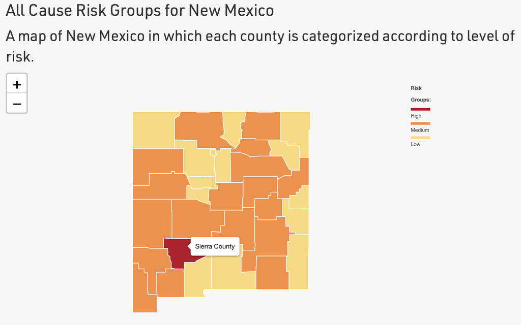

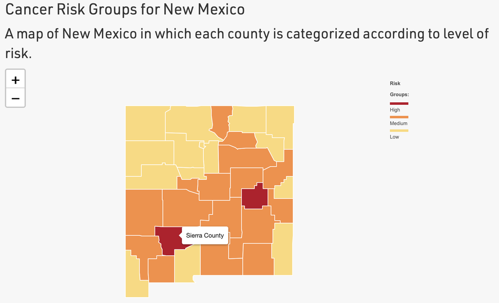

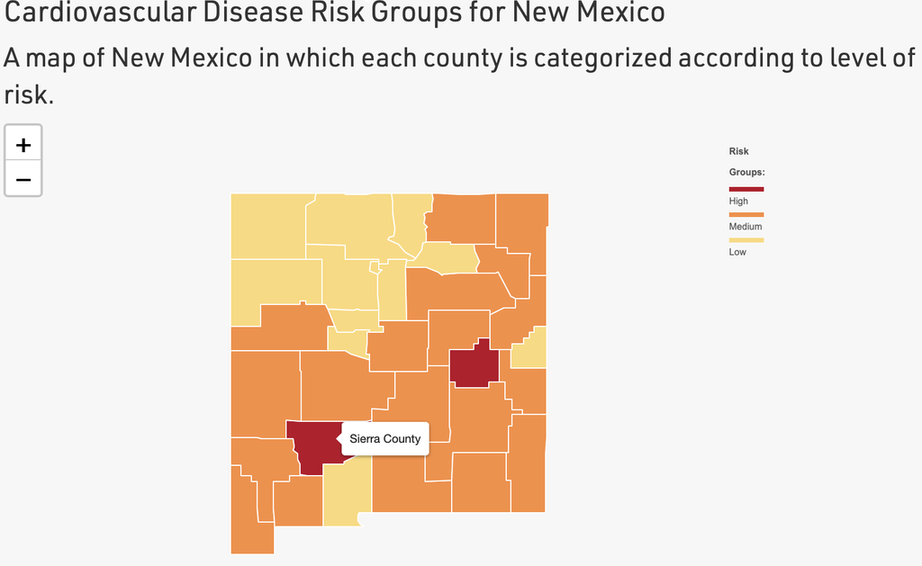

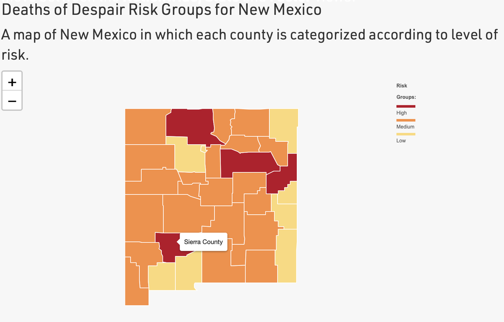